# Assignment 6

In this assignment, you'll analyze a collection of data sets from the [San Francisco Open Data Portal](http://data.sfgov.org/) and [Zillow](https://www.zillow.com/). The data sets have been stored in the SQLite database `sf_data.sqlite`, which you can [download here](http://anson.ucdavis.edu/~nulle/sf_data.sqlite). The database contains the following tables:

| Table | Description |
| --- | --- |
| `crime` | Crime reports dating back to 2010. |
| `mobile_food_locations` | List of all locations where mobile food vendors sell. |
| `mobile_food_permits` | List of all mobile food vendor permits. More details [here](https://data.sfgov.org/api/views/rqzj-sfat/files/8g2f5RV4PEk0_b24iJEtgEet9gnh_eA27GlqoOjjK4k?download=true&filename=DPW_DataDictionary_Mobil… |
| `mobile_food_schedule` | Schedules for mobile food vendors. |
| `noise` | Noise complaints dating back to August 2015. |
| `parking` | List of all parking lots. |
| `parks` | List of all parks. |
| `schools` | List of all schools. |
| `zillow` | Zillow rent and housing statistics dating back to 1996. More details [here](https://www.zillow.com/research/data/). |

The `mobile_food_` tables are explicitly connected through the `locationid` and `permit` columns. The other tables are not connected, but you may be able to connect them using dates, latitude/longitude, or postal codes.

Shapefiles for US postal codes are available [here](https://www.census.gov/geo/maps-data/data/cbf/cbf_zcta.html). These may be useful for converting latitude/longitude to postal codes.

Shapefiles for San Francisco Neighborhoods are available [here](https://data.sfgov.org/Geographic-Locations-and-Boundaries/SF-Find-Neighborhoods/pty2-tcw4).

**Exercise 1.1.** Which mobile food vendor(s) sells at the most locations?

```python
import sqlite3 as sql
import pandas as pd
```

```python
query = '''
SELECT
perm.Applicant Vendor, COUNT(DISTINCT sche.locationid) locations
FROM
mobile_food_schedule sche
INNER JOIN
mobile_food_permits perm ON perm.permit = sche.permit
WHERE
perm.Status = 'APPROVED'
OR
perm.Status = 'ONLINE'
OR
perm.Status = 'ISSUED'
GROUP BY Applicant
ORDER BY locations DESC
''' #query for sql, extract appropriate vendors and their locations

conn = sql.connect('copysf.sqlite') #connect to db
vendor_locs = pd.read_sql(query, conn) #to pd dataframe
pd.read_sql(query + 'LIMIT 10', conn) #or directly take top 10 from db
# conn.close() #close connection
```

|  | Vendor | locations |
| --- | --- | --- |
| 0 | Park's Catering | 23 |
| 1 | D & T Catering | 17 |
| 2 | F & C Catering | 13 |
| 3 | Munch A Bunch | 10 |
| 4 | Eva's Catering | 8 |
| 5 | BH & MT LLC | 7 |
| 6 | Linda's Catering | 7 |
| 7 | Golden Catering | 5 |
| 8 | Roadside Rotisserie Corporation / Country Grill | 5 |
| 9 | San Francisco Carts & Concessions, Inc. DBA St... | 5 |

In order to find the number of locations at which the various vendors sell, we extract the relevant information using the above sql query. The schedule and permit tables are joined in order to select just the ones for which the permit status is 'approved', 'online', or 'issued' since we want just currently active locations. Above is the top 10 vendors according to number of locations. Parks Catering tops the list with 23 locations.

**Exercise 1.2.** Ask and use the database to analyze 5 questions about San Francisco. For each question, write at least 150 words and support your answer with plots. Make a map for at least 2 of the 5 questions.

You should try to come up with some questions on your own, but these are examples of reasonable questions:

- Which parts of the city are the most and least expensive?
- Which parts of the city are the most dangerous (and at what times)?
- Are noise complaints and mobile food vendors related?
- What are the best times and places to find food trucks?
- Is there a relationship between housing prices and any of the other tables?

Please make sure to clearly state each of your questions in your submission.

```python
#necessary imports for following parts
from mpl_toolkits.basemap import Basemap
import numpy as np
%matplotlib inline
import matplotlib.pyplot as plt
plt.rcParams['figure.figsize'] = (12, 12)
import calendar
```

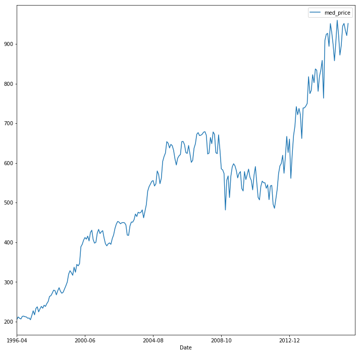

```python
#1.2 (1) How has the SF median home price per square foot changed over the past 20 years?
q1 = '''
SELECT
substr(Date,0,8) Date,
AVG(MedianSoldPricePerSqft_AllHomes) med_price
FROM
zillow
WHERE substr(Date,0,5) != '2017'
GROUP BY Date
''' #query for med price averaged over all regions of SF
home_price = pd.read_sql(q1, conn) #to dataframe

home_price.plot('Date', 'med_price') #pd.plot avg. median price vs date
```

## (1) How has the SF median home price per square foot changed over the past 20 years?

```python
#1.2 (2) Where to find mobile food for a given time and day?

# conn = sql.connect('copysf.sqlite')
# conn.execute('''UPDATE mobile_food_schedule
#     SET StartHour = 12
#     WHERE StartHour = 0''')
# conn.execute('''UPDATE mobile_food_schedule
#     SET EndHour = 12
#     WHERE EndHour = 0''')
# conn.commit()
# conn.close()

#code above used for updating the Start and End hour in the mobile_food_schedule table to change 0 hours into 12


def find_food(time, day):
    '''
    This function takes in a time and a day and returns a dataframe of the info. for available mobile food places
    Input: time INT, day Str (day of the week)
    Output: pd.Dataframe with cols. StartHour, Endhour, Vendor, Day, and Address
    '''
    conn = sql.connect('copysf.sqlite') #connect
    day = day[:2] #substring to match in database
    #query to extract entries matching the conditions
    quer = '''
    SELECT DISTINCT
    StartHour, EndHour, Applicant Vendor, DayOfWeek Day, Address
    FROM
    mobile_food_schedule sche
    INNER JOIN
    mobile_food_permits perm ON perm.permit = sche. permit
    INNER JOIN
    mobile_food_locations loc ON loc.locationid = sche.locationid
    WHERE
    (Status = 'APPROVED' OR Status = 'ONLINE' OR Status = 'ISSUED')
    AND Day LIKE '%''' + "%s' AND %d BETWEEN StartHour AND EndHour-1" %(day,time)
    db = pd.read_sql(quer, conn) #to df
    conn.close() #close connection
    return db
WeekDayCount = 0 #initialize count
for Day in list(calendar.day_name)[:5]:
    WeekDayCount += len(find_food(12,Day))
ave_wd = WeekDayCount / 5.0 #average count for the 5 weekdays

WeekendCount = 0
for Day in list(calendar.day_name)[5:]:
    WeekendCount += len(find_food(12,Day))
ave_wk = WeekendCount / 2.0 #average count for the 2 weekend days
find_food(12,'sat').head(10) #example lunch on saturday
```

|  | StartHour | EndHour | Vendor | Day | Address |
| --- | --- | --- | --- | --- | --- |
| 0 | 6 | 16 | HALAL SF GYRO | Sa | 1301 MARKET ST |
| 1 | 9 | 17 | Linda's Catering | Sa | 1219 07TH AVE |
| 2 | 8 | 20 | Tacos Rodriguez | Sa | 1275 EVANS AVE |
| 3 | 8 | 16 | DO UC US Mobile Catering | Sa | 2590 MARIN ST |
| 4 | 10 | 21 | Got Snacks | Sa | 1020 03RD ST |
| 5 | 8 | 16 | Munch A Bunch | Sa | 1850 MISSION ST |
| 6 | 7 | 20 | San Pancho's Tacos | Sa | 3119 ALEMANY BLVD |
| 7 | 11 | 22 | Subs on Hubs | Sa | Assessors Block 8711/Lot021 |
| 8 | 6 | 21 | The New York Frankfurter Co. of CA, Inc. DBA: ... | Sa | 101 STOCKTON ST |
| 9 | 10 | 20 | Kabob Trolley, LLC | Sa | 298 KING ST |

## (2) Where to find mobile food for a given time and day? Are there more vendors during weekdays or weekend?

Examining mobile food vendors and their schedule, the function ‘find_food’ is built to make use of sql to find the address, schedule, and name of available vendors for a given day and time. The query involves joining all three mobile food tables to extract vendors who are actively selling. This means only certain permit status qualifies. Results are filtered by the given day and given time. Regarding the time, only entries satisfying the condition of being between the StartHour column and EndHour column – 1 are returned. This gives at least 1 hour to eat. As an example, looking at lunch hour (12pm), surprisingly, mobile food vendors also take the weekend off as opposed to during the weekdays. The average places to eat during weekdays at 12 is 55.2 while during Saturday and Sunday is only 18.5. Using sql, the hours were modified using the update command, changing 0 hours into 12 p.m. since 12 a.m. doesn’t make much sense with the scheduling.

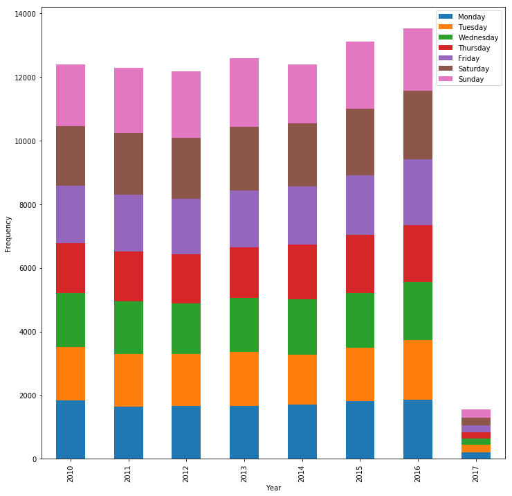

```python
#1.2 (3) What are the various frequencies of assault in SF by day and year?
q2 = '''
SELECT DayOfWeek Day, substr(DateTime, 0,5) Year, COUNT(DayOfWeek) Freq
from crime
WHERE
Category = 'ASSAULT'
group by Year, DayOfWeek
''' #Group count by day and year
df = pd.read_sql(q2, conn)
#reshape the dataframe for ease of plotting, days of the weeks are now columns
assault_day_year = pd.DataFrame(np.array(df.Freq).reshape(8,7), columns=[day for day in df.Day[:7]])
dayList = list(calendar.day_name) #ordered list of calender days
assault = assault_day_year.reindex(columns=[dayList]) #reorder the columns
assault['Year'] = range(2010,2018) #new columns for year
assault = assault.set_index('Year') #set year column as index

assault.plot.bar(stacked = True) #plot stacked bars for each year
plt.ylabel('Frequency')
plt.xlabel('Year')
```

## (3) What are the various frequencies of assault in SF by day and year? (2010-2017)

Looking at the frequency of instances of assault for the past seven years (2010-2016, some 2017), the day of the week and year is extracted from the crime table. Assaults are counted and grouped by each day of the week and by each year. A stacked bar plot is created to show count as well as relative count for each year along the x-axis. Monday through Sunday are color-coded and stacked on top of one another. It appears that generally, there is not a standout day for which the assault count is significantly different from the rest. However, Thursdays do tend to consistently have the fewest assault counts except for 2015 when Tuesday was lowest. Generally, Saturday and Sunday show higher relative counts than the weekdays. In fact, for all the years except 2016, these two days consistently show highest assault counts. So far in 2017 (up to Feb), this trend is holding true.

```python
from matplotlib.patches import Polygon
from matplotlib.collections import PatchCollection
from matplotlib.colors import Normalize
import matplotlib.cm
```

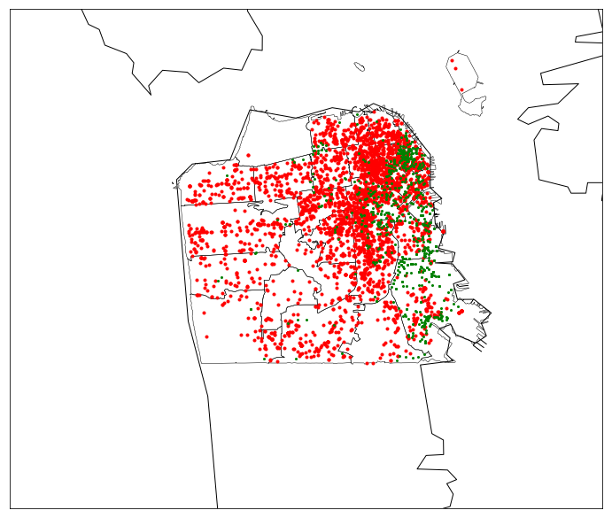

```python
#1.2 (4) Where are the noise complaints vs. locations of mobile food facilities?
q3 = '''
SELECT
Lon nLon, Lat nLat
FROM
noise
WHERE
nLon IS NOT NULL
''' #lon lat from noise
q4 = '''
SELECT
Longitude fLon, Latitude fLat
FROM
mobile_food_locations
WHERE
fLon IS NOT NULL AND fLon != 0.0
''' #lon lat from mobile food locations

noise_lonlat = pd.read_sql(q3, conn) #df for noise lon, lat
food_lonlat = pd.read_sql(q4, conn) #for mobile food
lonlat_df = pd.concat([noise_lonlat, food_lonlat], axis=1) #combined df

#basemap draw, zoom on SF
my_map = Basemap(llcrnrlon=-122.6, llcrnrlat=37.65, urcrnrlon=-122.3, urcrnrlat=37.85, resolution="h",
    projection="merc"
)
my_map.drawcoastlines()
#use shape file for different zip code sections for just SF (faster than all U.S.)
my_map.readshapefile("sfzip/geo_export_63e29a55-a573-4028-8f51-c560f9a3db05", "areas")

x, y = my_map(lonlat_df.nLon.values, lonlat_df.nLat.values) #plot all noise locations
my_map.plot(x, y, 'r.')
x, y = my_map(lonlat_df.fLon.values, lonlat_df.fLat.values) #plot all mobile food locations
my_map.plot(x,y, 'go', markersize = 2)
```

## (4) Where are the noise complaints vs. locations of mobile food facilities?

Examining the possible relationship between noise complaints and mobile food vendors in terms of geographical clustering, a crude map of San Francisco is drawn. All Latitudes and Longitudes are extracted from each of the two relevant tables. These values are then used to plot locations as small dots. While noise complaints, are spread out everywhere on this map, there is a significantly larger cluster in the north easternmost corner of the city. Mobile food vendors seem to have much smaller confines for where they tend to sell. Unsurprisingly, this concentration is also towards the northeastern side of SF. While there are reasons for believing the relationship between mobile food and noise complaints is significant, I think the simpler explanation prevails here. Namely, this is where you would typically find the most popular areas like ATT Park. Tourist attractions and city-dwelling concentration in this part of SF may be more so responsible for the overlap (correlation) as opposed to causation. Furthermore, some mobile food locations seems to be within the absence of noise complaints.

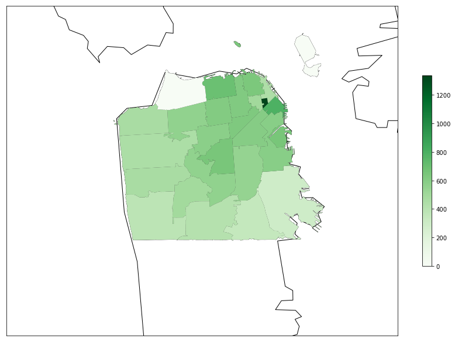

```python
#1.2 (5) Where are the most expensive areas in SF by zipcode?
q5 = '''
SELECT
RegionName zip, AVG(MedianSoldPricePerSqft_AllHomes) ave_med_price
FROM
zillow
GROUP BY zip
ORDER BY ave_med_price DESC
''' #averaged over years, grouped by zip code regions
home_med_price = pd.read_sql(q5, conn)

map = Basemap(llcrnrlon=-122.6, llcrnrlat=37.65, urcrnrlon=-122.3, urcrnrlat=37.85, resolution="h",
    projection="merc"
) #basemap obj.

fig, ax = plt.subplots(figsize=(15,15)) #subplots for color filling
map.drawcoastlines()
#shapefile for zip code separated regions
map.readshapefile("sfzip/geo_export_63e29a55-a573-4028-8f51-c560f9a3db05", "zipcodes")

df_poly = pd.DataFrame({ #df, values for drawing shapes
        'shapes': [Polygon(np.array(shape), True) for shape in map.zipcodes],
        'zip': [int(e['zip']) for e in map.zipcodes_info]
        })
df_poly = df_poly.merge(home_med_price, on='zip', how='left') #combine price and corresponding shape

cmap = plt.get_cmap('Greens') #color map, green shades
pc = PatchCollection(df_poly.shapes, zorder=2)
norm = Normalize()
#fill color according to average median price per region
pc.set_facecolor(cmap(norm(df_poly['ave_med_price'].fillna(0).values)))
ax.add_collection(pc)

mapper = matplotlib.cm.ScalarMappable(norm=norm, cmap=cmap)

mapper.set_array(df_poly['ave_med_price'])
plt.colorbar(mapper, shrink=0.4) #color codes, darker-more expensive
```

## (5) Where are the most expensive areas in SF by zipcode?

San Francisco living has been notoriously known for being quite expensive. Thus, we will examine average median sold price per square feet for all homes. This figure is an average (over time) for each area of San Francisco separated by postal codes. A map is drawn with the appropriate boundaries. Using the aforementioned calculated statistic as scale, shades of green will be filled into each region. Generally, the map shows darker shades in the northeastern section. The outermost parts of the city get progressively lighter. However, for the most parts, the differences are not too striking. It could be that, while particular areas of the city are more expensive than others, it is still by no means cheap to live in any part of SF. This is consistent with what we know about SF with regards to where the attractions and most densely populated areas are. We can see that even within a city like San Francisco, there are geographical shades, whether natural or artificial, in terms of the societal mosaic.